# Binomial Distribution Response to Urban Heat - Tacoma

| [Welcome](https://jmhulbert.github.io/redhot2) | [Data](https://jmhulbert.github.io/redhot2/data) | [Analyses](https://jmhulbert.github.io/redhot2/analyses) | [Discussion](https://jmhulbert.github.io/redhot2/discussion) | [Maps](https://jmhulbert.github.io/redhot2/maps) |
| --- | --- | --- | --- | --- |

|  |  |  | Analyses |  |  |  |
| --- | --- | --- | --- | --- | --- | --- |
| [Urban Heat](https://jmhulbert.github.io/redhot2/analyses/heat/) | [All Areas](https://jmhulbert.github.io/redhot2/analyses/heat/all-areas) | [Portland](https://jmhulbert.github.io/redhot2/analyses/heat/portland) | [Tacoma](https://jmhulbert.github.io/redhot2/analyses/heat/tacoma) | [King County](https://jmhulbert.github.io/redhot2/analyses/heat/king) | [iNaturalist](https://jmhulbert.github.io/redhot2/analyses/inaturalist/) | [City Inventories](https://jmhulbert.github.io/redhot2/analyses/city-trees/) |

```r
library(tidyverse)
library(corrplot)
library(knitr)
library(kableExtra)
library(gghalves)
library(patchwork)
library(scales)
library(glmmTMB)
library(bbmle)
library(DHARMa)
```

# Purpose

The purpose of this page is to summarize an investigation of **tree health categories** as a *categorical* response to urban heat (temperatures) for observations from Tacoma, WA.

Response variable: category: *healthy, unhealthy*

*Response variables* Binary health: healthy, unhealthy Binary dead top: no top dieback, top dieback Binary thinning: no thinning, thinning

# Data Wrangling

```r
data <- read.csv('https://raw.githubusercontent.com/jmhulbert/redhot2/refs/heads/main/data/urban-data-modified.csv')
```

## Remove dead trees

```r
# Remove Dead Trees
data.w.dead <- data
data <- data %>% filter(field.tree.canopy.symptoms!="Tree is dead") %>% filter(field.dieback.percent<100) %>% droplevels()
```

113 trees were dead

```r
data$binary.tree.canopy.symptoms <- as.factor(data$binary.tree.canopy.symptoms)
levels(data$binary.tree.canopy.symptoms)
```

```
## [1] "Healthy"   "Unhealthy"
```

## Filter to Tacoma Data

```r
data <- data %>% filter(Area=="Tacoma") %>% droplevels()
```

1413 trees were included in Tacoma

```r
data$top.dieback <- as.factor(data$top.dieback)
data$thinning <- as.factor(data$thinning)
```

## Remove Point Defiance Data (optional)

```r
pd.data <- data %>% filter(str_detect(place_guess, "Point Defiance") |str_detect(place_guess, "point defiance")) %>%  mutate(park = str_remove(place_guess, ",.*"))
```

770 trees were observed in Point Defiance (based on iNat place guess)

```r
data.no.pd <- data %>% filter(!str_detect(place_guess, "Point Defiance") & !str_detect(place_guess, "point defiance"))
```

643 trees were observed from throughout Tacoma, not including Point Defiance (based on iNat place guess)

# Visualize Tacoma Data

```r
#ggplot(data,aes(binary.tree.canopy.symptoms,tac.af.f,fill=binary.tree.canopy.symptoms))+geom_violin()+coord_flip()+theme_bw()+ scale_fill_manual(name="Tree Condition",values=c("#7fcdbb","#fe9929"))+guides(fill=FALSE)
```

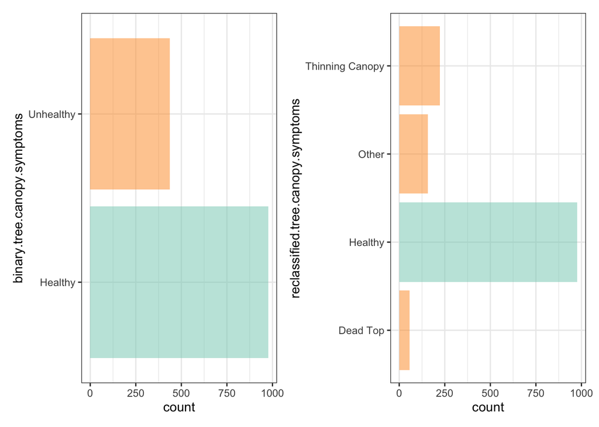

```r
p1 <- ggplot(data,aes(binary.tree.canopy.symptoms,fill=binary.tree.canopy.symptoms))+geom_histogram(stat="count",alpha=0.5)+theme_bw()+coord_flip()+ scale_fill_manual(values=c("#7fcdbb","#fe9929"))+guides(fill=FALSE)
p2 <- ggplot(data,aes(reclassified.tree.canopy.symptoms,fill=reclassified.tree.canopy.symptoms))+geom_histogram(stat="count",alpha=0.5)+theme_bw()+coord_flip()+ scale_fill_manual(values=c("#fe9929","#7fcdbb","#fe9929","#fe9929"))+guides(fill=FALSE)
p1 + p2
```

```r
#p3 <- ggplot(data,aes(binary.tree.canopy.symptoms)) +facet_wrap(~field.optional...tree.size) +geom_histogram(stat="count")+theme_bw()+coord_flip()
#p3
```

```r
#p4 <- ggplot(data,aes(binary.tree.canopy.symptoms)) +facet_wrap(~field.optional...site.location.description) +geom_histogram(stat="count")+theme_bw()+coord_flip()
#p4
```

```r
p5 <-ggplot(data,aes(binary.tree.canopy.symptoms,tac.af.f, fill=binary.tree.canopy.symptoms ))+geom_boxplot(alpha=0.5)+theme_bw()+coord_flip() + scale_fill_manual(name="Tree Condition",values=c("#7fcdbb","#fe9929"))+guides(fill=FALSE) +labs(x="Tree Condition",y=NULL)
```

```r
p6 <-ggplot(data,aes(tac.af.f,fill=binary.tree.canopy.symptoms))+geom_density(alpha=0.5) + scale_fill_manual(name="Tree Condition",values=c("#7fcdbb","#fe9929")) +theme_bw() +labs(x="Afternoon Temperature") +guides(fill=FALSE)
```

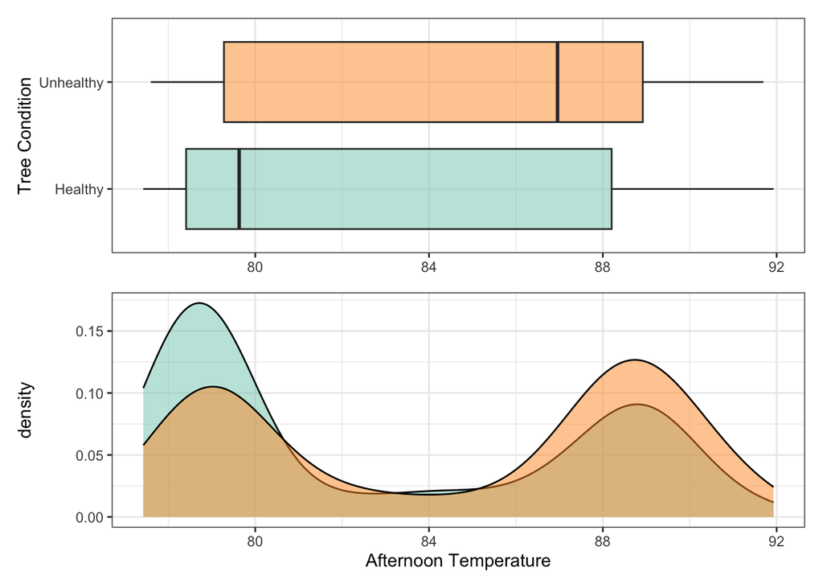

```r
p5 / p6
```

## Data without Point Defiance

```r
p7 <-ggplot(data.no.pd,aes(binary.tree.canopy.symptoms,tac.af.f, fill=binary.tree.canopy.symptoms))+geom_boxplot(alpha=0.5)+theme_bw()+coord_flip() + scale_fill_manual(name="Tree Condition",values=c("#7fcdbb","#fe9929"))+guides(fill=FALSE) +labs(x="Tree Condition",y=NULL)
```

```r
p8 <-ggplot(data.no.pd,aes(tac.af.f,fill=binary.tree.canopy.symptoms))+geom_density(alpha=0.5) + scale_fill_manual(name="Tree Condition",values=c("#7fcdbb","#fe9929")) +theme_bw() +labs(x="Afternoon Temperature") +guides(fill=FALSE)
```

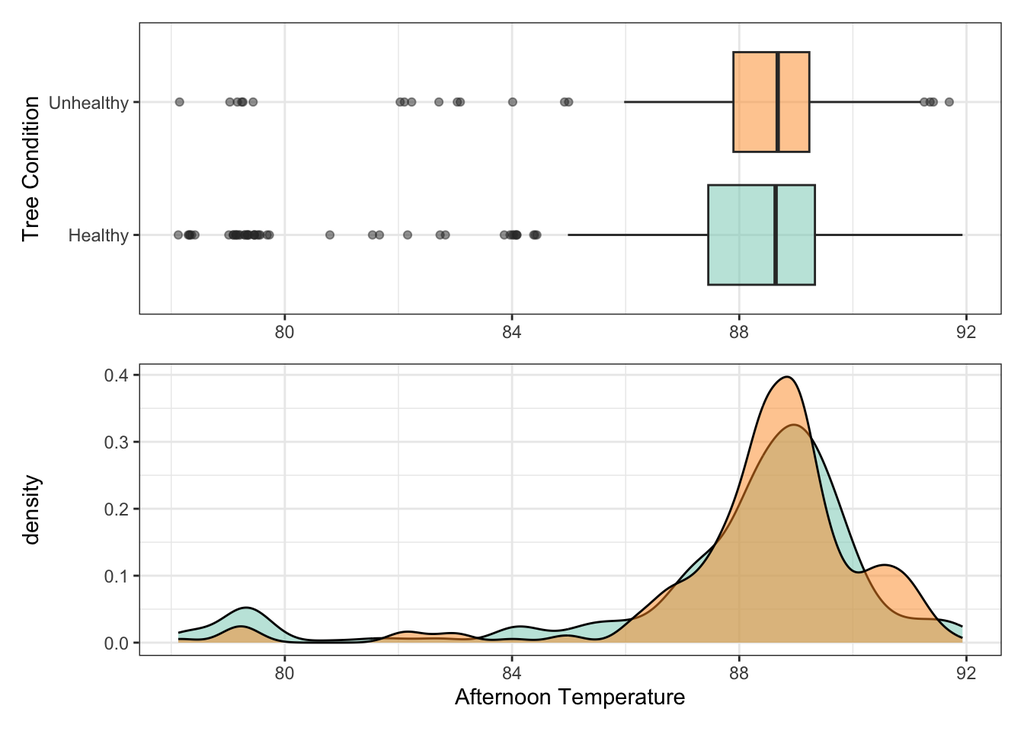

```r
p7 / p8
```

## Point Defiance Data Only

```r
p9 <-ggplot(pd.data,aes(binary.tree.canopy.symptoms,tac.af.f, fill=binary.tree.canopy.symptoms))+geom_boxplot(alpha=0.5)+theme_bw()+coord_flip() + scale_fill_manual(name="Tree Condition",values=c("#7fcdbb","#fe9929"))+guides(fill=FALSE) +labs(x="Tree Condition",y=NULL)
```

```r
p10 <-ggplot(pd.data,aes(tac.af.f,fill=binary.tree.canopy.symptoms))+geom_density(alpha=0.5) + scale_fill_manual(name="Tree Condition",values=c("#7fcdbb","#fe9929")) +theme_bw() +labs(x="Afternoon Temperature") +guides(fill=FALSE)
```

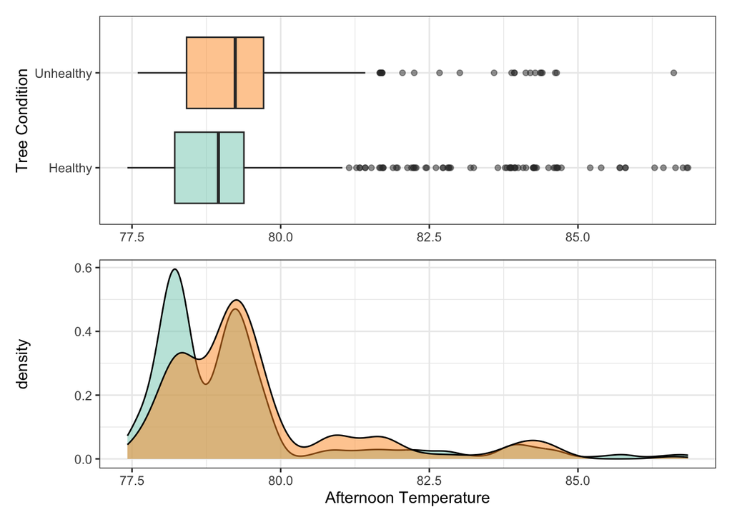

```r
p9 / p10
```

# Analyses

## Temperature Time Periods

```r
binomial.daily <- glmmTMB(binary.tree.canopy.symptoms ~ mean.temp.daily.f ,family=binomial,data=data)
binomial.am <- glmmTMB(binary.tree.canopy.symptoms ~ tac.am.f ,data=data,family=binomial)
binomial.af <- glmmTMB(binary.tree.canopy.symptoms ~ tac.af.f ,data=data,family=binomial)
binomial.pm <- glmmTMB(binary.tree.canopy.symptoms ~ tac.pm.f,data=data,family=binomial)
```

### Best Fit Comparison

```r
AICtab(binomial.daily,binomial.am,binomial.af,binomial.pm)
```

```
##                dAIC df
## binomial.pm     0.0 2
## binomial.af     2.8 2
## binomial.daily  4.8 2
## binomial.am    49.1 2
```

> Overnight heat was the best fit

## Response 1.0: healthy / unhealthy

```r
binomial.af <- glmmTMB(binary.tree.canopy.symptoms ~ tac.af.f, data=data,family=binomial)
```

### Summary

```r
summary(binomial.af)
```

```
##  Family: binomial  ( logit )
## Formula:          binary.tree.canopy.symptoms ~ tac.af.f
## Data: data
##
##       AIC       BIC    logLik -2*log(L)  df.resid
##    1705.6    1716.1    -850.8    1701.6      1411
##
##
## Conditional model:
##             Estimate Std. Error z value Pr(>|z|)
## (Intercept) -7.61718    1.01829  -7.480 7.41e-14 ***
## tac.af.f     0.08144    0.01210   6.729 1.71e-11 ***
## ---
## Signif. codes:  0 '***' 0.001 '**' 0.01 '*' 0.05 '.' 0.1 ' ' 1
```

Tree health is associated with urban heat. The probability of success (tree categorized as unhealthy) increases with urban heat

Unhealthy trees are considered success (1) because it is the second level. The probability of failure (0) is the first level (Healthy).

```r
levels(data$binary.tree.canopy.symptoms)
```

```
## [1] "Healthy"   "Unhealthy"
```

The probability of a tree being classified as unhealthy increases with urban temperature.

### Visualize effects of predictors

First, generate predictions from model

```r
# Create a data frame for predictions
new.data <- expand.grid(
  tac.af.f = seq(min(data$tac.af.f), max(data$tac.af.f), length.out = 100)  # keeping predictor2 constant at its mean
)
```

```r
new.data$predicted_response <- predict(binomial.af, newdata = new.data, type = "response")
```

```r
head(new.data)
```

```
##   tac.af.f predicted_response
## 1 77.42253          0.2122087
## 2 77.56907          0.2142108
## 3 77.71562          0.2162266
## 4 77.86216          0.2182561
## 5 78.00870          0.2202993
## 6 78.15525          0.2223561
```

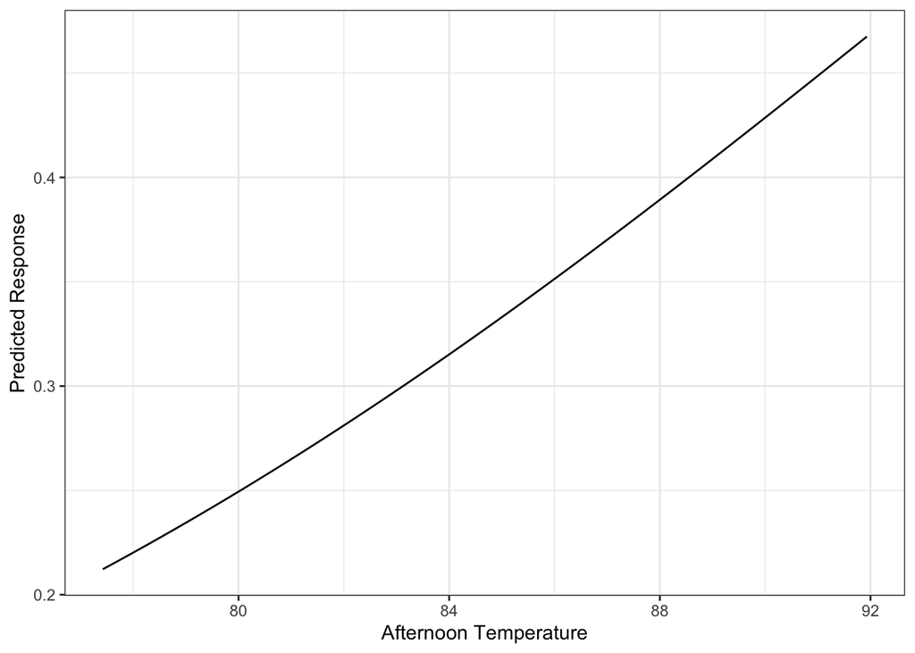

```r
ggplot(new.data, aes(x = tac.af.f, y = predicted_response)) +
  geom_line() +
  labs(x = "Afternoon Temperature", y = "Predicted Response") +
  theme_bw()
```

The probability of tree being classified as unhealthy increases with afternoon temperature

### Compare without Point Defiance Data

```r
binomial.af <- glmmTMB(binary.tree.canopy.symptoms ~ tac.af.f, data=data.no.pd,family=binomial)
```

### Summary

```r
summary(binomial.af)
```

```
##  Family: binomial  ( logit )
## Formula:          binary.tree.canopy.symptoms ~ tac.af.f
## Data: data.no.pd
##
##       AIC       BIC    logLik -2*log(L)  df.resid
##     855.5     864.4    -425.7     851.5       641
##
##
## Conditional model:
##             Estimate Std. Error z value Pr(>|z|)
## (Intercept) -8.50039    3.01558  -2.819  0.00482 **
## tac.af.f     0.09136    0.03419   2.672  0.00754 **
## ---
## Signif. codes:  0 '***' 0.001 '**' 0.01 '*' 0.05 '.' 0.1 ' ' 1
```

## Response 2.0: healthy / top-dieback

```r
data.top <- data %>% filter(reclassified.tree.canopy.symptoms=="Healthy"|reclassified.tree.canopy.symptoms=="Dead Top") %>% droplevels()
```

```r
top.dieback.binomial.af <- glmmTMB(top.dieback ~ tac.af.f,data=data.top,family=binomial)
```

### Summary

```r
summary(top.dieback.binomial.af)
```

```
##  Family: binomial  ( logit )
## Formula:          top.dieback ~ tac.af.f
## Data: data.top
##
##       AIC       BIC    logLik -2*log(L)  df.resid
##     378.1     388.0    -187.0     374.1      1030
##
##
## Conditional model:
##              Estimate Std. Error z value Pr(>|z|)
## (Intercept) -24.85536    3.56267  -6.977 3.02e-12 ***
## tac.af.f      0.25719    0.04063   6.331 2.44e-10 ***
## ---
## Signif. codes:  0 '***' 0.001 '**' 0.01 '*' 0.05 '.' 0.1 ' ' 1
```

```r
levels(data$top.dieback)
```

```
## [1] "No"  "Yes"
```

The probability of a tree having top dieback increases with urban temperature.

### Visualize effects of predictors

First, generate predictions from model

```r
# Create a data frame for predictions
new.data.2 <- expand.grid(
  tac.af.f = seq(min(80), max(150), length.out = 1000)  # keeping predictor2 constant at its mean
)
```

```r
head(new.data.2)
```

```
##   tac.af.f
## 1 80.00000
## 2 80.07007
## 3 80.14014
## 4 80.21021
## 5 80.28028
## 6 80.35035
```

```r
new.data.2$predicted_response <- predict(top.dieback.binomial.af, newdata = new.data.2, type = "response")
```

```r
# Create a data frame for predictions
new.data.2.inf <- expand.grid(
  tac.af.f = seq(min(data.top$tac.af.f), max(150), length.out = 1000)  # keeping predictor2 constant at its mean
)
```

```r
new.data.2.inf$predicted_response <- predict(top.dieback.binomial.af, newdata = new.data.2.inf, type = "response")
```

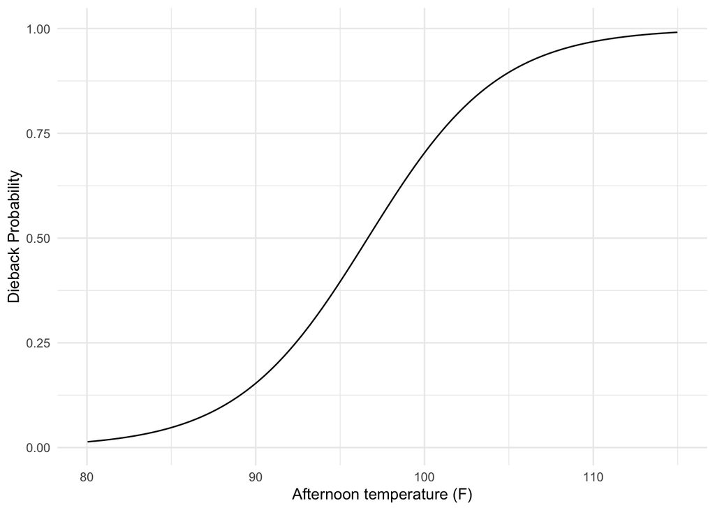

```r
p <- ggplot(new.data.2.inf, aes(x = tac.af.f, y = predicted_response)) + geom_line() + labs(x = "Afternoon temperature (F)", y = "Dieback Probability") + scale_x_continuous(limits = c(80, 115)) +theme_minimal()

p
```

### Calculate Dieback Probability Categories

```r
head(new.data.2[new.data.2$tac.af.f<83.7 & new.data.2$tac.af.f>83,])
```

```
##    tac.af.f predicted_response
## 44 83.01301         0.02915662
## 45 83.08308         0.02967108
## 46 83.15315         0.03019434
## 47 83.22322         0.03072654
## 48 83.29329         0.03126782
## 49 83.36336         0.03181831
```

Tacoma redcedar at 83.12 degrees had a 0.03 probability

```r
head(new.data.2[new.data.2$predicted_response>0.024 & new.data.2$predicted_response<0.028,])
```

```
##    tac.af.f predicted_response
## 33 82.24224         0.02403969
## 34 82.31231         0.02446615
## 35 82.38238         0.02489997
## 36 82.45245         0.02534129
## 37 82.52252         0.02579023
## 38 82.59259         0.02624690
```

Tacoma redcedar at 82.42 degrees had a 0.025 probability

```r
head(new.data.2[new.data.2$predicted_response>0.048 & new.data.2$predicted_response<0.052,])
```

```
##    tac.af.f predicted_response
## 73 85.04505         0.04820573
## 74 85.11512         0.04903934
## 75 85.18519         0.04988661
## 76 85.25526         0.05074773
## 77 85.32533         0.05162292
```

Tacoma trees at 85.25 had about a 0.05 probability

```r
head(new.data.2[new.data.2$predicted_response>0.095,])
```

```
##     tac.af.f predicted_response
## 114 87.91792         0.09586782
## 115 87.98799         0.09744125
## 116 88.05806         0.09903768
## 117 88.12813         0.10065735
## 118 88.19820         0.10230050
## 119 88.26827         0.10396738
```

Tacoma redcedar at about 88.1 degrees had a 0.1 predicted response.

```r
head(new.data.2[new.data.2$predicted_response>0.24 & new.data.2$predicted_response<0.26,])
```

```
##     tac.af.f predicted_response
## 175 92.19219          0.2414553
## 176 92.26226          0.2447713
## 177 92.33233          0.2481180
## 178 92.40240          0.2514952
## 179 92.47247          0.2549027
## 180 92.54254          0.2583405
```

Tacoma redcedar at about 92.36 degrees had a 0.25 predicted response.

Convert to Celsius

85.25 = 29.6 88.1 = 31.2

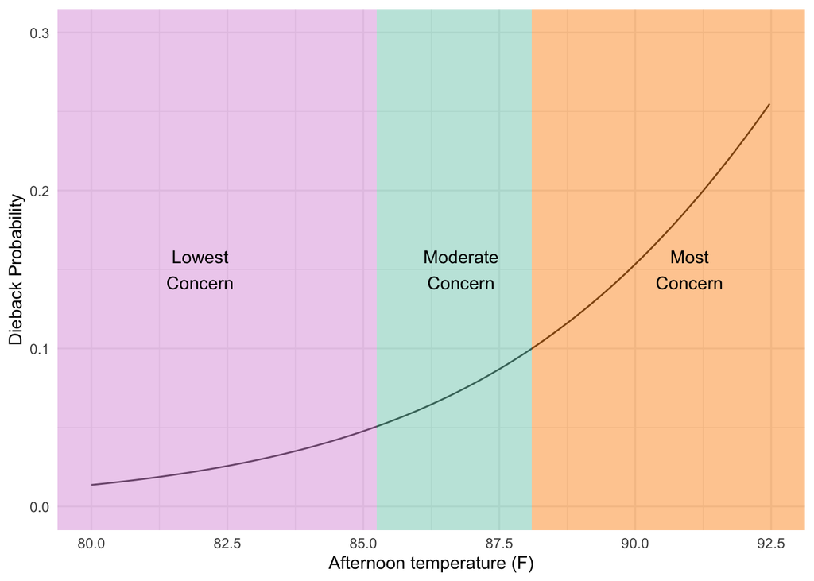

```r
p <- ggplot(new.data.2, aes(x = tac.af.f, y = predicted_response)) + geom_line() + labs(x = "Afternoon temperature (F)", y = "Dieback Probability") + scale_x_continuous(limits = c(80, 92.5),breaks=c(80,82.5,85,87.5,90,92.5)) + scale_y_continuous(limits = c(0, .3)) +theme_minimal()

p2 <- p + annotate(geom="rect",ymin = -Inf, ymax = Inf,
              xmin = -Inf, xmax = 85.25, fill = alpha('#DDA0DD',0.5)) +
    annotate(geom="rect",ymin = -Inf, ymax = Inf,
              xmin = 85.25, xmax = 88.1, fill = alpha('#7fcdbb',0.5)) +
    annotate(geom="rect",ymin = -Inf, ymax = Inf,
          xmin = 88.1, xmax = Inf, fill = alpha('#fe9929',0.5))
p3 <- p2 + annotate("text", x=82, y=.15, label= "Lowest\nConcern") + annotate("text", x=86.8, y=.15, label= "Moderate\nConcern") + annotate("text", x=91, y=.15, label= "Most\nConcern")
p3
```

## Response 3.0: healthy / thinning

```r
data.thin <- data %>% filter(reclassified.tree.canopy.symptoms=="Healthy"|reclassified.tree.canopy.symptoms=="Thinning Canopy") %>% droplevels()
```

```r
thinning.binomial.af <- glmmTMB(thinning ~ tac.af.f,data=data.thin,family=binomial)
```

### Summary

```r
summary(thinning.binomial.af)
```

```
##  Family: binomial  ( logit )
## Formula:          thinning ~ tac.af.f
## Data: data.thin
##
##       AIC       BIC    logLik -2*log(L)  df.resid
##    1141.6    1151.8    -568.8    1137.6      1197
##
##
## Conditional model:
##             Estimate Std. Error z value Pr(>|z|)
## (Intercept) -6.30177    1.28925  -4.888 1.02e-06 ***
## tac.af.f     0.05787    0.01536   3.768 0.000165 ***
## ---
## Signif. codes:  0 '***' 0.001 '**' 0.01 '*' 0.05 '.' 0.1 ' ' 1
```

```r
levels(data.thin$thinning)
```

```
## [1] "No"  "Yes"
```

```r
str(data.thin$thinning)
```

```
##  Factor w/ 2 levels "No","Yes": 1 1 1 1 1 1 1 1 1 1 ...
```

### Visualize effects of predictors

First, generate predictions from model

```r
# Create a data frame for predictions
new.data.3 <- expand.grid(
  tac.af.f = seq(min(data.thin$tac.af.f), max(data.thin$tac.af.f), length.out = 100),  # keeping predictor2 constant at its mean
  Area = 0  # assuming random effect is zero for prediction
)
```

```r
new.data.3$predicted_response <- predict(thinning.binomial.af, newdata = new.data.3, type = "response")
```

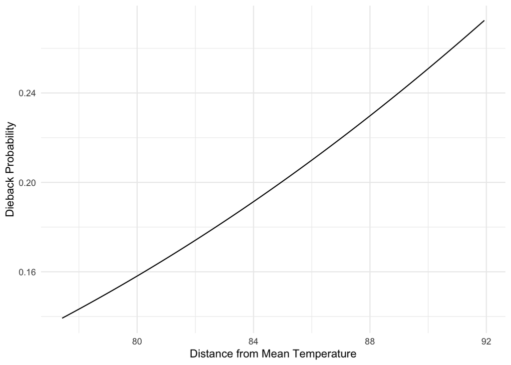

```r
ggplot(new.data.3, aes(x = tac.af.f, y = predicted_response)) +
  geom_line() +
  labs(x = "Distance from Mean Temperature", y = "Dieback Probability") +
  theme_minimal()
```